# Project2-DataScience

Abanoub Mimi, Amir George, Tony Foti

May 8, 2016

# Exploratory analysis

We begin by attaching required libraries and loading the datasets and relevant classifiers.

```r
library(dplyr)
library(knitr)
library(RWeka)
library(tidyr)
library(ggplot2)
```

```r
trainDf <- read.csv('data/train.csv')
testDf <- read.csv('data/test.csv')
contractRefDf <- read.csv('data/contract_ref.csv')
calendarRefDf <- read.csv('data/calendar_ref.csv')
dailyAggDf <- read.csv('data/daily_aggregate.csv', nrows = 1000)
roamingDf <- read.csv('data/roaming_monthly.csv')
```

```r
trainDf$TARGET <- as.factor(trainDf$TARGET)
RF <- make_Weka_classifier("weka/classifiers/trees/RandomForest")
NB <- make_Weka_classifier("weka/classifiers/bayes/NaiveBayes")
MLP <- make_Weka_classifier("weka/classifiers/functions/MultilayerPerceptron")
```

Examine the graph for sample of users’ usage where the target is 1 and 0

```r
monthly_names <- c('206','207','208','209','210')
monthly_usage_columns <- c('X206_USAGE','X207_USAGE','X208_USAGE','X209_USAGE','X210_USAGE')
avgs_monthly_usages <- c(mean(trainDf$X206_USAGE),mean(trainDf$X207_USAGE),mean(trainDf$X208_USAGE),mean(trainDf$X209_USAGE),mean(trainDf$X210_USAGE))

trainDfTarget1 <- trainDf %>% filter(TARGET == 1)
trainDfTarget0 <- trainDf %>% filter(TARGET == 0)

avgs_monthly_usages_traget_1 <- c(mean(trainDfTarget1$X206_USAGE),mean(trainDfTarget1$X207_USAGE),mean(trainDfTarget1$X208_USAGE),mean(trainDfTarget1$X209_USAGE),mean(trainDfTarget1$X210_USAGE))

avgs_monthly_sessions_count_traget_1 <-
c(mean(trainDfTarget1$X206_SESSION_COUNT),mean(trainDfTarget1$X207_SESSION_COUNT),mean(trainDfTarget1$X208_SESSION_COUNT),mean(trainDfTarget1$X209_SESSION_COUNT),mean(trainDfTarget1$X210_SESSION_COUNT))

avgs_monthly_usages_target_0 <- c(mean(trainDfTarget0$X206_USAGE),mean(trainDfTarget0$X207_USAGE),mean(trainDfTarget0$X208_USAGE),mean(trainDfTarget0$X209_USAGE),mean(trainDfTarget0$X210_USAGE))

avgs_monthly_sessions_count_traget_0 <- c(mean(trainDfTarget0$X206_SESSION_COUNT),mean(trainDfTarget0$X207_SESSION_COUNT),mean(trainDfTarget0$X208_SESSION_COUNT),mean(trainDfTarget0$X209_SESSION_COUNT),mean(trainDfTarget0$X210_SESSION_COUNT))

df <- data.frame(monthly_names, avgs_monthly_usages_traget_1, avgs_monthly_usages_target_0, avgs_monthly_sessions_count_traget_1, avgs_monthly_sessions_count_traget_0)
```

From the figure below we can have two observaitions: 1. The value is 1 when the rate of changes tends to increase over the 5 months. 2. The value is 1 for the users who used big usages in the last 5 months(roughly greater than 2500MB).

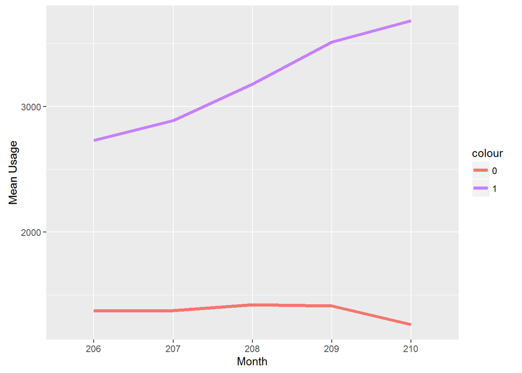

```r
ggplot(df, aes(monthly_names)) +
  geom_line(aes(y = avgs_monthly_usages_traget_1, colour='1'), size=1.5, group = 1) +
  geom_line(aes(y = avgs_monthly_usages_target_0, colour= '0'), size= 1.5, group = 1) +
  xlab("Month")+ylab("Mean Usage")  +
  scale_colour_manual(values=c("#F57670","#C680FC"))
```

The same as the mean for usage when the target is 1 However, we can notice that bump in the middle of thers users where the target is 0.

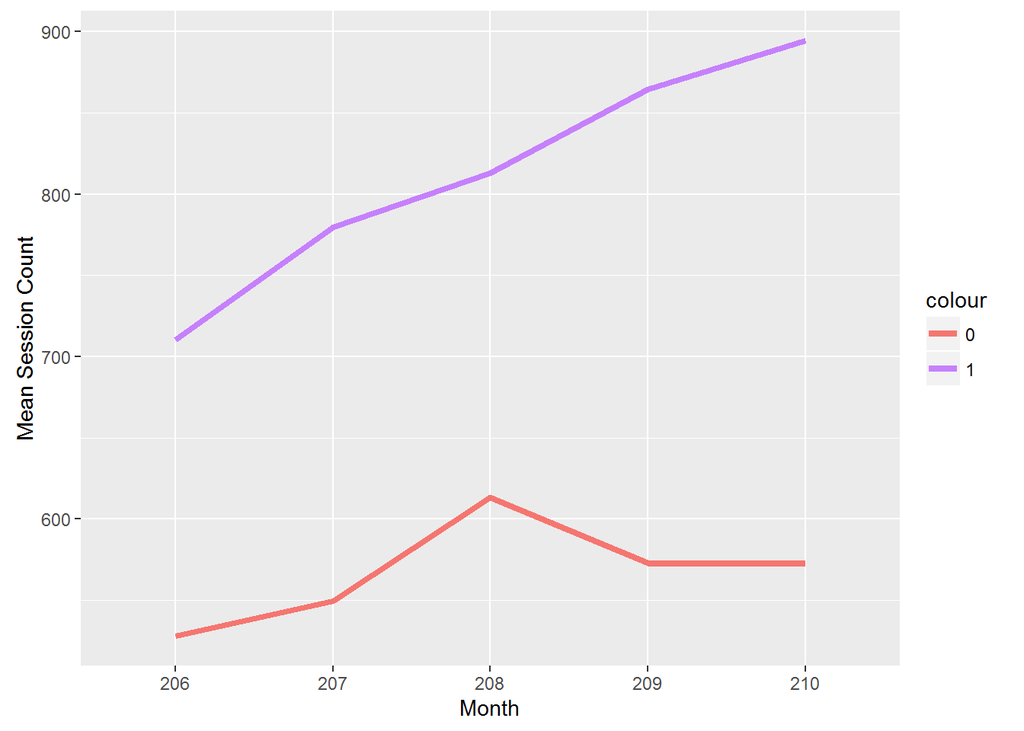

```r
ggplot(df, aes(monthly_names)) +
  geom_line(aes(y = avgs_monthly_sessions_count_traget_1, colour='1'), size=1.5, group = 1) +
  geom_line(aes(y = avgs_monthly_sessions_count_traget_0, colour= '0'), size= 1.5, group = 1) +
  xlab("Month")+ylab("Mean Session Count")  +
  scale_colour_manual(values=c("#F57670","#C680FC"))
```

```r
trainDf <- trainDf %>% rowwise() %>% mutate(diff1 = X207_USAGE - X206_USAGE, diff2 = X208_USAGE-X207_USAGE, diff3=X209_USAGE-X208_USAGE,diff4=X210_USAGE-X209_USAGE, always_increasing = (diff1 > 0 & diff2 > 0 & diff3 >0 & diff4 > 0))
```

## Explore Daily Agg. Data(Mimi)

```r
dailyAggDf %>% dim
```

```
## [1] 1000    6
```

```r
summary(dailyAggDf) %>% kable
```

|  | CONTRACT_KEY | CALL_DATE_KEY | CELL_KEY | ROAMING_FLAG | TOTAL_CONSUMPTION | NO_OF_SESSIONS |
| --- | --- | --- | --- | --- | --- | --- |
|  | Min. :142405133 | Min. :6337 | Min. :6393501 | LOCAL :496 | Min. : 0 | Min. : 1.00 |
|  | 1st Qu.:145690027 | 1st Qu.:6340 | 1st Qu.:6783166 | ROAMING:504 | 1st Qu.: 0 | 1st Qu.: 1.00 |
|  | Median :149703324 | Median :6350 | Median :6805205 | NA | Median : 0 | Median : 1.00 |
|  | Mean :148771146 | Mean :6348 | Mean :6796969 | NA | Mean : 3470404 | Mean : 2.04 |
|  | 3rd Qu.:151729819 | 3rd Qu.:6350 | 3rd Qu.:6816317 | NA | 3rd Qu.: 512000 | 3rd Qu.: 1.00 |
|  | Max. :156182781 | Max. :6365 | Max. :6870561 | NA | Max. :273100800 | Max. :77.00 |

The unique number of cells

```r
dailyAggDf$CELL_KEY %>% unique %>% length
```

```
## [1] 891
```

The number of users we have their data

```r
dailyAggDf %>% group_by(CONTRACT_KEY) %>% summarise(sum = sum(TOTAL_CONSUMPTION)) %>%nrow()
```

```
## [1] 625
```

The number of users who belong to the train set

```r
dailyAggDf %>% group_by(CONTRACT_KEY) %>%  summarise(sum = sum(TOTAL_CONSUMPTION))  %>% merge(trainDf,BY = "DATE_KEY") %>%nrow()
```

```
## [1] 450
```

The number of users who belong to the test set

```r
dailyAggDf %>% group_by(CONTRACT_KEY) %>%  summarise(sum = sum(TOTAL_CONSUMPTION))  %>% merge(testDf,BY = "DATE_KEY") %>%nrow()
```

```
## [1] 175
```

We merge the daily data with the agg to get more info to each record

```r
colnames(dailyAggDf)[2] <- "DATE_KEY"
daily_calendar_merge <- merge(dailyAggDf, calendarRefDf, BY = "DATE_KEY")
```

We found that total consumption is measured by bytes so we convert it to MB

```r
daily_calendar_merge$TOTAL_CONSUMPTION <- daily_calendar_merge$TOTAL_CONSUMPTION/1024/1024
```

### 25- For each user in the daily agg table we calculate for each day, the amount of usage and sessions whether local or roaming in that day. But we don’t have the data for all the users so, we calculate their usage or sesions count as the total over 7 (the seven days) equally.(Mimi)

```r
  trainDf$TARGET <- as.factor(trainDf$TARGET)
  colnames(dailyAggDf)[2] <- "DATE_KEY"
  a <- merge(dailyAggDf, calendarRefDf, BY = "DATE_KEY")
  a$TOTAL_CONSUMPTION <- a$TOTAL_CONSUMPTION/1024/1024

  trainRoamDf <- trainDf
  testRoamDf <- testDf

  trainRoamDf[,"R206_USAGE"] <- 0
  trainRoamDf[,"R206_SESSION_COUNT"] <- 0
  trainRoamDf[,"R207_USAGE"] <- 0
  trainRoamDf[,"R207_SESSION_COUNT"] <- 0
  trainRoamDf[,"R208_USAGE"] <- 0
  trainRoamDf[,"R208_SESSION_COUNT"] <- 0
  trainRoamDf[,"R209_USAGE"] <- 0
  trainRoamDf[,"R209_SESSION_COUNT"] <- 0
  trainRoamDf[,"R210_USAGE"] <- 0
  trainRoamDf[,"R210_SESSION_COUNT"] <- 0


  testRoamDf[,"R206_USAGE"] <- 0
  testRoamDf[,"R206_SESSION_COUNT"] <- 0
  testRoamDf[,"R207_USAGE"] <- 0
  testRoamDf[,"R207_SESSION_COUNT"] <- 0
  testRoamDf[,"R208_USAGE"] <- 0
  testRoamDf[,"R208_SESSION_COUNT"] <- 0
  testRoamDf[,"R209_USAGE"] <- 0
  testRoamDf[,"R209_SESSION_COUNT"] <- 0
  testRoamDf[,"R210_USAGE"] <- 0
  testRoamDf[,"R210_SESSION_COUNT"] <- 0

  for (k in unique(roamingDf$CONTRACT_KEY)) {
    orig <- roamingDf[roamingDf$CONTRACT_KEY==k,]
    if (trainRoamDf[trainRoamDf$CONTRACT_KEY==k,] %>% nrow > 0) {
      val <- orig[orig$CALL_MONTH_KEY == 206,]
      if (nrow(val) > 0) {
        trainRoamDf[trainRoamDf$CONTRACT_KEY==k,"R206_USAGE"] = val$USAGE
        trainRoamDf[trainRoamDf$CONTRACT_KEY==k,"R206_SESSION_COUNT"] = val$SESSION_COUNT
      }
      val <- orig[orig$CALL_MONTH_KEY == 207,]
      if (nrow(val) > 0) {
        trainRoamDf[trainRoamDf$CONTRACT_KEY==k,"R207_USAGE"] = val$USAGE
        trainRoamDf[trainRoamDf$CONTRACT_KEY==k,"R207_SESSION_COUNT"] = val$SESSION_COUNT
      }
      val <- orig[orig$CALL_MONTH_KEY == 208,]
      if (nrow(val) > 0) {
        trainRoamDf[trainRoamDf$CONTRACT_KEY==k,"R208_USAGE"] = val$USAGE
        trainRoamDf[trainRoamDf$CONTRACT_KEY==k,"R208_SESSION_COUNT"] = val$SESSION_COUNT
      }
      val <- val[val$CALL_MONTH_KEY == 209,]
      if (nrow(val) > 0) {
        trainRoamDf[trainRoamDf$CONTRACT_KEY==k,"R209_USAGE"] = val$USAGE
        trainRoamDf[trainRoamDf$CONTRACT_KEY==k,"R209_SESSION_COUNT"] = val$SESSION_COUNT
      }
      val <- orig[orig$CALL_MONTH_KEY == 210,]
      if (nrow(val) > 0) {
        trainRoamDf[trainRoamDf$CONTRACT_KEY==k,"R210_USAGE"] = val$USAGE
        trainRoamDf[trainRoamDf$CONTRACT_KEY==k,"R210_SESSION_COUNT"] = val$SESSION_COUNT
      }
    }
    else {
      val <- orig[orig$CALL_MONTH_KEY == 206,]
      if (nrow(val) > 0) {
        testRoamDf[testRoamDf$CONTRACT_KEY==k,"R206_USAGE"] = val$USAGE
        testRoamDf[testRoamDf$CONTRACT_KEY==k,"R206_SESSION_COUNT"] = val$SESSION_COUNT
      }
      val <- orig[orig$CALL_MONTH_KEY == 207,]
      if (nrow(val) > 0) {
        testRoamDf[testRoamDf$CONTRACT_KEY==k,"R207_USAGE"] = val$USAGE
        testRoamDf[testRoamDf$CONTRACT_KEY==k,"R207_SESSION_COUNT"] = val$SESSION_COUNT
      }
      val <- orig[orig$CALL_MONTH_KEY == 208,]
      if (nrow(val) > 0) {
        testRoamDf[testRoamDf$CONTRACT_KEY==k,"R208_USAGE"] = val$USAGE
        testRoamDf[testRoamDf$CONTRACT_KEY==k,"R208_SESSION_COUNT"] = val$SESSION_COUNT
      }
      val <- val[val$CALL_MONTH_KEY == 209,]
      if (nrow(val) > 0) {
        testRoamDf[testRoamDf$CONTRACT_KEY==k,"R209_USAGE"] = val$USAGE
        testRoamDf[testRoamDf$CONTRACT_KEY==k,"R209_SESSION_COUNT"] = val$SESSION_COUNT
      }
      val <- orig[orig$CALL_MONTH_KEY == 210,]
      if (nrow(val) > 0) {
        testRoamDf[testRoamDf$CONTRACT_KEY==k,"R210_USAGE"] = val$USAGE
        testRoamDf[testRoamDf$CONTRACT_KEY==k,"R210_SESSION_COUNT"] = val$SESSION_COUNT
      }
    }
  }

  trainRoamDf <- trainRoamDf %>% mutate(X206_SESSION_COUNT = X206_SESSION_COUNT - R206_SESSION_COUNT,
                                        X206_USAGE = X206_USAGE - R206_USAGE,
                                        X207_SESSION_COUNT = X207_SESSION_COUNT - R207_SESSION_COUNT,
                                        X207_USAGE = X207_USAGE - R207_USAGE,
                                        X208_SESSION_COUNT = X208_SESSION_COUNT - R208_SESSION_COUNT,
                                        X208_USAGE = X208_USAGE - R208_USAGE,
                                        X209_SESSION_COUNT = X209_SESSION_COUNT - R209_SESSION_COUNT,
                                        X209_USAGE = X209_USAGE - R209_USAGE,
                                        X210_SESSION_COUNT = X210_SESSION_COUNT - R210_SESSION_COUNT,
                                        X210_USAGE = X210_USAGE - R210_USAGE)

  testRoamDf <- testRoamDf %>% mutate(X206_SESSION_COUNT = X206_SESSION_COUNT - R206_SESSION_COUNT,
                                        X206_USAGE = X206_USAGE - R206_USAGE,
                                        X207_SESSION_COUNT = X207_SESSION_COUNT - R207_SESSION_COUNT,
                                        X207_USAGE = X207_USAGE - R207_USAGE,
                                        X208_SESSION_COUNT = X208_SESSION_COUNT - R208_SESSION_COUNT,
                                        X208_USAGE = X208_USAGE - R208_USAGE,
                                        X209_SESSION_COUNT = X209_SESSION_COUNT - R209_SESSION_COUNT,
                                        X209_USAGE = X209_USAGE - R209_USAGE,
                                        X210_SESSION_COUNT = X210_SESSION_COUNT - R210_SESSION_COUNT,
                                        X210_USAGE = X210_USAGE - R210_USAGE)

  monthly_usage_columns <- c('X206_USAGE','X207_USAGE','X208_USAGE','X209_USAGE','X210_USAGE')
  weekdays <- c('Saturday','Sunday','Monday','Tuesday','Wednesday','Thursday','Friday')

  train.df <- trainRoamDf
  test.df  <- testRoamDf

    for(name in weekdays){
      # Local Data
      col_name_usage <- paste('local_',name,'_usage',sep='')
      col_name_sessions_count <- paste('local_',name,'_sessions_count',sep='')
      filtered_data <- a %>% filter(ROAMING_FLAG == "LOCAL" & DAY_NAME == name)

      exp <- paste("filtered_data %>% group_by(CONTRACT_KEY) %>%
        summarise(", col_name_usage, "= sum(TOTAL_CONSUMPTION),",col_name_sessions_count,"=sum(NO_OF_SESSIONS) )", sep = "")
      local <- eval(parse(text = exp))
      train.df <- merge(train.df,local, BY = "CONTRACT_KEY",all.x = T)
      test.df <- merge(test.df,local, BY = "CONTRACT_KEY",all.x = T)

      ##Remove Na's
      #local usage
      exp <- paste("train.df <- train.df %>% mutate(",col_name_usage,"= ifelse(is.na(",col_name_usage,"),X210_USAGE/7,",col_name_usage,"))", sep= "")
      eval(parse(text = exp))

      #local sessions count
      exp <- paste("train.df <- train.df %>% mutate(",col_name_sessions_count,"= ifelse(is.na(",col_name_sessions_count,"),X210_SESSION_COUNT/7,",col_name_sessions_count,"))", sep= "")
      eval(parse(text = exp))

      ##Remove Na's
      #testing
      exp <- paste("test.df <- test.df %>% mutate(",col_name_usage,"= ifelse(is.na(",col_name_usage,"),X210_USAGE/7,",col_name_usage,"))", sep= "")
      eval(parse(text = exp))

      exp <- paste("test.df <- test.df %>% mutate(",col_name_sessions_count,"= ifelse(is.na(",col_name_sessions_count,"),X210_SESSION_COUNT/7,",col_name_sessions_count,"))", sep= "")
      eval(parse(text = exp))

      #Roaming Data
      col_name_usage <- paste('roaming_',name,'_usage',sep='')
      col_name_sessions_count <- paste('roaming_',name,'_sessions_count',sep='')

      filtered_data <- a %>% filter(ROAMING_FLAG == "ROAMING" & DAY_NAME == name)
      exp <- paste("filtered_data %>% group_by(CONTRACT_KEY) %>%
        summarise(", col_name_usage, "= sum(TOTAL_CONSUMPTION),",col_name_sessions_count,"=sum(NO_OF_SESSIONS) )", sep = "")
      roaming <- eval(parse(text = exp))
      train.df <- merge(train.df,roaming, BY = "CONTRACT_KEY",all.x = T)
      test.df <- merge(test.df,roaming, BY = "CONTRACT_KEY",all.x = T)

      ##Remove Na's
      #roamiming usage
      exp <- paste("train.df <- train.df %>% mutate(",col_name_usage,"= ifelse(is.na(",col_name_usage,"),R210_USAGE/7,",col_name_usage,"))", sep= "")
      eval(parse(text = exp))

      #roamiming sessions count
      exp <- paste("train.df <- train.df %>% mutate(",col_name_sessions_count,"= ifelse(is.na(",col_name_sessions_count,"),R210_SESSION_COUNT/7,",col_name_sessions_count,"))", sep= "")
      eval(parse(text = exp))

      ##Remove Na's
      #roamiming usage
      exp <- paste("test.df <- test.df %>% mutate(",col_name_usage,"= ifelse(is.na(",col_name_usage,"),R210_USAGE/7,",col_name_usage,"))", sep= "")
      eval(parse(text = exp))

      #local sessions count
      exp <- paste("test.df <- test.df %>% mutate(",col_name_sessions_count,"= ifelse(is.na(",col_name_sessions_count,"),R210_SESSION_COUNT/7,",col_name_sessions_count,"))", sep= "")
      eval(parse(text = exp))
  }
```

### 26- From the previous columns now we can caluclate more features like week_day_usage, week_end_usage and the same for the sessions count(Mimi). After that the score improved to

```r
  ## Train
  train.df <- train.df %>% rowwise() %>% mutate(
    weekday_usage = sum(c(local_Sunday_usage,roaming_Sunday_usage,local_Monday_usage,roaming_Monday_usage,local_Tuesday_usage,roaming_Tuesday_usage,local_Wednesday_usage,roaming_Wednesday_usage,local_Thursday_usage,roaming_Thursday_usage))
    ,
    weekday_sessions_count = sum(c(local_Sunday_sessions_count,roaming_Sunday_sessions_count,local_Monday_sessions_count,roaming_Monday_sessions_count,local_Tuesday_sessions_count,roaming_Tuesday_sessions_count,local_Wednesday_sessions_count,roaming_Wednesday_sessions_count,local_Thursday_sessions_count,roaming_Thursday_sessions_count))
    ,
    weekend_usage = sum(c(local_Friday_usage,roaming_Friday_usage,local_Saturday_usage,roaming_Saturday_usage))
    ,
    weekend_sessions_count = sum(c(local_Friday_sessions_count,roaming_Friday_sessions_count,local_Saturday_sessions_count,roaming_Saturday_sessions_count))
   )

  ## Test
  test.df <- test.df %>% rowwise() %>% mutate(
    weekday_usage = sum(c(local_Sunday_usage,roaming_Sunday_usage,local_Monday_usage,roaming_Monday_usage,local_Tuesday_usage,roaming_Tuesday_usage,local_Wednesday_usage,roaming_Wednesday_usage,local_Thursday_usage,roaming_Thursday_usage))
    ,
    weekday_sessions_count = sum(c(local_Sunday_sessions_count,roaming_Sunday_sessions_count,local_Monday_sessions_count,roaming_Monday_sessions_count,local_Tuesday_sessions_count,roaming_Tuesday_sessions_count,local_Wednesday_sessions_count,roaming_Wednesday_sessions_count,local_Thursday_sessions_count,roaming_Thursday_sessions_count))
    ,
    weekend_usage = sum(c(local_Friday_usage,roaming_Friday_usage,local_Saturday_usage,roaming_Saturday_usage))
    ,
    weekend_sessions_count = sum(c(local_Friday_sessions_count,roaming_Friday_sessions_count,local_Saturday_sessions_count,roaming_Saturday_sessions_count))
   )
```

```r
   train.df <- train.df %>% rowwise() %>% mutate(
    mean_usage = mean(c(X206_USAGE,X207_USAGE,X208_USAGE,X209_USAGE,X210_USAGE)),

    sd_usage =sd(c(X206_USAGE,X207_USAGE,X208_USAGE,X209_USAGE,X210_USAGE)),

    median_usage = median(c(X206_USAGE,X207_USAGE,X208_USAGE,X209_USAGE,X210_USAGE) ),

    mean_sessions_count=mean(c(X206_SESSION_COUNT,X207_SESSION_COUNT,X208_SESSION_COUNT,X209_SESSION_COUNT,X210_SESSION_COUNT)),

    median_sessions_count=median(c(X206_SESSION_COUNT,X207_SESSION_COUNT,
      X208_SESSION_COUNT,X209_SESSION_COUNT,X210_SESSION_COUNT)),

    sd_sessions_count=sd(c(X206_SESSION_COUNT,X207_SESSION_COUNT,X208_SESSION_COUNT,X209_SESSION_COUNT,X210_SESSION_COUNT))
    )

  test.df <- test.df %>% rowwise() %>% mutate(
    mean_usage = mean(c(X206_USAGE,X207_USAGE,X208_USAGE,X209_USAGE,X210_USAGE)),

    sd_usage =sd(c(X206_USAGE,X207_USAGE,X208_USAGE,X209_USAGE,X210_USAGE)),

    median_usage = median(c(X206_USAGE,X207_USAGE,X208_USAGE,X209_USAGE,X210_USAGE) ),

    mean_sessions_count=mean(c(X206_SESSION_COUNT,X207_SESSION_COUNT,X208_SESSION_COUNT,X209_SESSION_COUNT,X210_SESSION_COUNT)),

    median_sessions_count=median(c(X206_SESSION_COUNT,X207_SESSION_COUNT,
      X208_SESSION_COUNT,X209_SESSION_COUNT,X210_SESSION_COUNT)),

    sd_sessions_count=sd(c(X206_SESSION_COUNT,X207_SESSION_COUNT,X208_SESSION_COUNT,X209_SESSION_COUNT,X210_SESSION_COUNT))
    )
```

We also tried to take average of probilites between two classifiers. We used Decision Forest and Neural network but the result wasn’t so encouring 0.65652.

### Ensemble Kaggle Submissions(Mimi)

We tried to improve our score by ensembling the submissions. We calculted the correlation between submissions using this pythong script which posted in Kaggle-Ensemble-Guide repo correlations.py. when choosing high-correlated submissions the score change slightly (which makes sense), the score changed from 0.70053 to 0.70071 when we choosed scripts 25 and 26 with weights 1, 3 respectively using this kaggle_vote.py.

We also tried to ensmable low-correlated submissions like scripts 36 and 26 and give AUC score 0.68192

# CrossValidation between different models(Mimi)

We did the cross validation on Microsoft Azure beacuse our local machinse could’nt stand this big laod.

Cross validation for the first train columns.

```r
summary <- crossValidation %>% group_by(Model) %>% summarise(accuracy = mean(Accuracy), precision = mean(Precision),recall = mean(Recall), F.Score = mean(F.Score), AUC = mean(AUC))
summary %>% kable
```

| Model | accuracy | precision | recall | F.Score | AUC |
| --- | --- | --- | --- | --- | --- |
| Bayes Point | 0.7346481 | 0.5179601 | 0.0467268 | 0.0855359 | 0.6793212 |
| Binary Neural Network | 0.7325643 | 0.4597906 | 0.0411947 | 0.0749491 | 0.6709569 |
| Decision Forest Classifier | 0.7437830 | 0.5328407 | 0.2030223 | 0.2936428 | 0.7423799 |
| Decision Jungle Classifier | 0.7303949 | 0.4478821 | 0.2102188 | 0.2859521 | 0.6898601 |
| FastTree (Boosted Trees) Classification | 0.7326522 | 0.0000000 | 0.0000000 | 0.0000000 | 0.7025295 |
| Local Deep SVM (LDSVM) | 0.7317354 | 0.4548433 | 0.0910134 | 0.1496510 | 0.6762043 |
| SVM (Pegasos-Linear) | 0.7343150 | 0.4951100 | 0.0606894 | 0.1079852 | 0.6864385 |

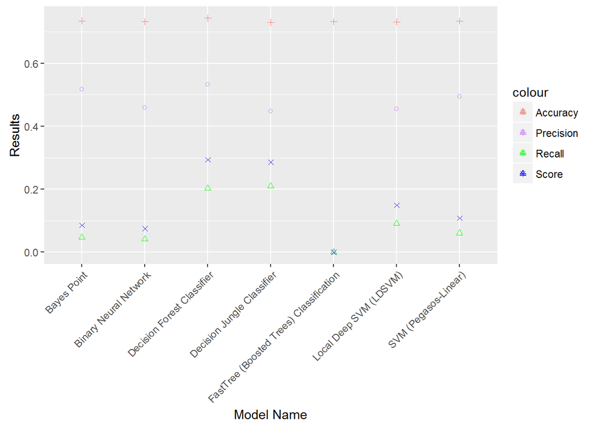

```r
NN_percisions <- c(summary[2,3]$precision)
DF_precisions <- c(summary[3,3]$precision)
SVM_precisions <- c(summary[7,3]$precision)
NN_acc <- c(summary[2,2]$accuracy)
DF_acc <- c(summary[3,2]$accuracy)
SVM_acc <- c(summary[7,2]$accuracy)

ggplot(summary, aes(Model)) +
  geom_point(aes(y = precision, colour ='Precision'), size=1.5, group = 1, shape=1) +
  geom_point(aes(y = recall, colour = 'Recall'), size= 1.5, group = 1, shape=2)+
  geom_point(aes(y = accuracy, colour = 'Accuracy'), size= 1.5, group = 1, shape=3)+
  geom_point(aes(y = F.Score, colour = 'Score'), size= 1.5, group = 1, shape=4)+
  xlab("Model Name")+ylab("Results")  +
  scale_colour_manual(values=c("#F57670","#C680FC","GREEN","BLUE"))+
  #scale_shape_discrete(solid=T, legend=F) +
  theme(axis.text.x = element_text(angle = 45, hjust = 1))
```

Cross validation for the model with the roaming columns added - script `13`

```r
summary <- crossValidation %>% group_by(Model) %>% summarise(accuracy = mean(Accuracy), precision = mean(Precision),recall = mean(Recall), F.Score = mean(F.Score), AUC = mean(AUC))
summary %>% kable
```

| Model | accuracy | precision | recall | F.Score | AUC |
| --- | --- | --- | --- | --- | --- |
| Bayes Point | 0.7348142 | 0.4976370 | 0.0741455 | 0.1289134 | 0.6786810 |
| Binary Neural Network | 0.7370411 | 0.5544772 | 0.0678571 | 0.1202245 | 0.7166437 |
| Decision Forest Classifier | 0.7447773 | 0.5439843 | 0.1953528 | 0.2872460 | 0.7430288 |
| Decision Jungle Classifier | 0.7322817 | 0.4576892 | 0.2093885 | 0.2870935 | 0.6894177 |
| FastTree (Boosted Trees) Classification | 0.7326522 | 0.0000000 | 0.0000000 | 0.0000000 | 0.7142510 |
| Local Deep SVM (LDSVM) | 0.7382626 | 0.5484349 | 0.1101179 | 0.1781303 | 0.6696837 |
| SVM (Pegasos-Linear) | 0.7353470 | 0.5391224 | 0.0476045 | 0.0868643 | 0.6563819 |

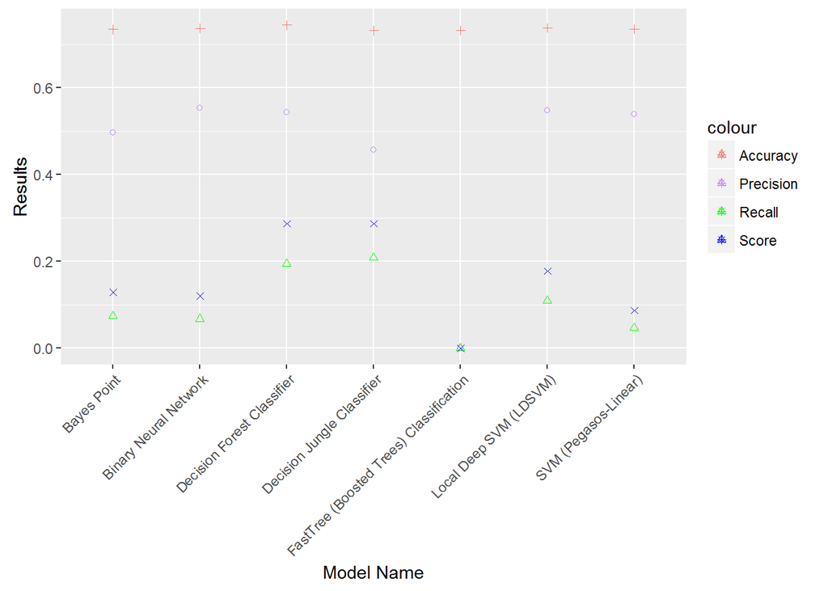

```r
NN_percisions <- c(NN_percisions,summary[2,3]$precision)
DF_precisions <- c(DF_precisions,summary[3,3]$precision)
SVM_precisions <- c(SVM_precisions,summary[7,3]$precision)
NN_acc <- c(NN_acc,summary[2,2]$accuracy)
DF_acc <- c(DF_acc,summary[3,2]$accuracy)
SVM_acc <- c(SVM_acc,summary[7,2]$accuracy)


ggplot(summary, aes(Model)) +
  geom_point(aes(y = precision, colour ='Precision'), size=1.5, group = 1, shape=1) +
  geom_point(aes(y = recall, colour = 'Recall'), size= 1.5, group = 1, shape=2)+
  geom_point(aes(y = accuracy, colour = 'Accuracy'), size= 1.5, group = 1, shape=3)+
  geom_point(aes(y = F.Score, colour = 'Score'), size= 1.5, group = 1, shape=4)+
  xlab("Model Name")+ylab("Results")  +
  scale_colour_manual(values=c("#F57670","#C680FC","GREEN","BLUE"))+
  #scale_shape_discrete(solid=T, legend=F) +
  theme(axis.text.x = element_text(angle = 45, hjust = 1))
```

Cross validation for the model with the daily columns added - Script 25

```r
summary <- crossValidation %>% group_by(Model) %>% summarise(accuracy = mean(Accuracy), precision = mean(Precision),recall = mean(Recall), F.Score = mean(F.Score), AUC = mean(AUC))
summary %>% kable
```

| Model | accuracy | precision | recall | F.Score | AUC |
| --- | --- | --- | --- | --- | --- |
| Bayes Point | 0.7339793 | 0.4891014 | 0.0560079 | 0.1003416 | 0.6798530 |
| Binary Neural Network | 0.7362806 | 0.6254634 | 0.0366768 | 0.0688901 | 0.7338194 |
| Decision Forest Classifier | 0.7431217 | 0.5351113 | 0.1866202 | 0.2764525 | 0.7413275 |
| Decision Jungle Classifier | 0.7323808 | 0.4584608 | 0.2062698 | 0.2844771 | 0.6924104 |
| FastTree (Boosted Trees) Classification | 0.7326522 | 0.0000000 | 0.0000000 | 0.0000000 | 0.7029698 |
| Local Deep SVM (LDSVM) | 0.7369052 | 0.5065202 | 0.1166120 | 0.1892887 | 0.7201698 |
| SVM (Pegasos-Linear) | 0.7349026 | 0.5169958 | 0.0504371 | 0.0917080 | 0.6982722 |

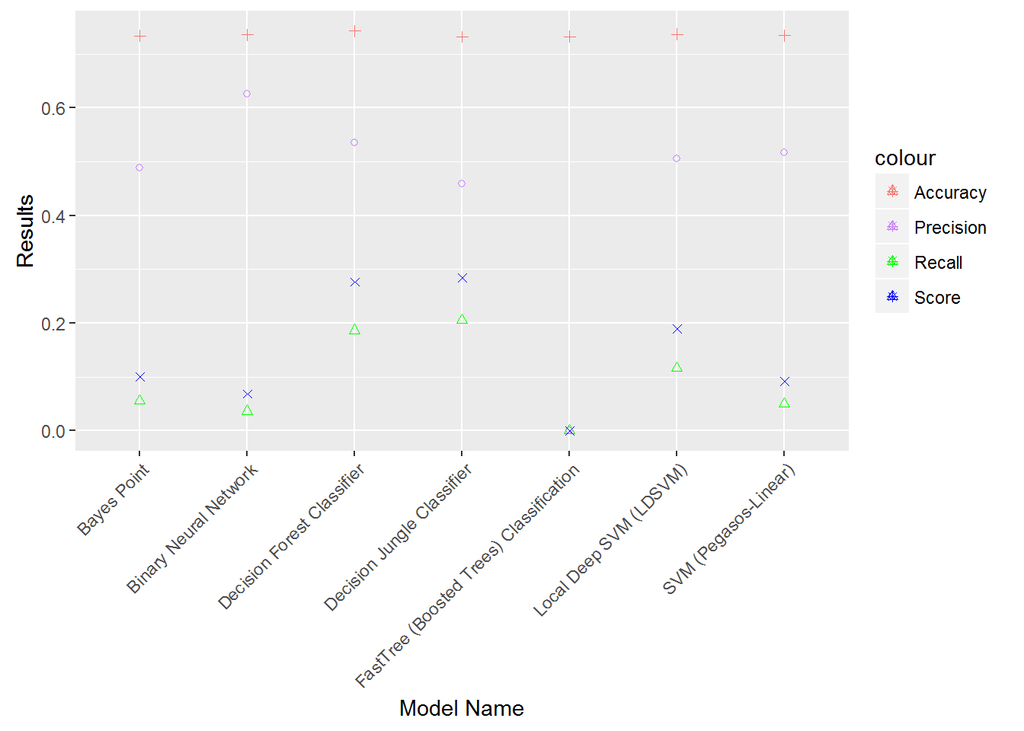

```r
NN_percisions <- c(NN_percisions,summary[2,3]$precision)
DF_precisions <- c(DF_precisions,summary[3,3]$precision)
SVM_precisions <- c(SVM_precisions,summary[7,3]$precision)
NN_acc <- c(NN_acc,summary[2,2]$accuracy)
DF_acc <- c(DF_acc,summary[3,2]$accuracy)
SVM_acc <- c(SVM_acc,summary[7,2]$accuracy)

ggplot(summary, aes(Model)) +
  geom_point(aes(y = precision, colour ='Precision'), size=1.5, group = 1, shape=1) +
  geom_point(aes(y = recall, colour = 'Recall'), size= 1.5, group = 1, shape=2)+
  geom_point(aes(y = accuracy, colour = 'Accuracy'), size= 1.5, group = 1, shape=3)+
  geom_point(aes(y = F.Score, colour = 'Score'), size= 1.5, group = 1, shape=4)+
  xlab("Model Name")+ylab("Results")  +
  scale_colour_manual(values=c("#F57670","#C680FC","GREEN","BLUE"))+
  #scale_shape_discrete(solid=T, legend=F) +
  theme(axis.text.x = element_text(angle = 45, hjust = 1))
```

Here is the cross validation for the model with the daily columns added - Script 26

```r
summary <- crossValidation %>% group_by(Model) %>% summarise(accuracy = mean(Accuracy), precision = mean(Precision),recall = mean(Recall), F.Score = mean(F.Score), AUC = mean(AUC))
summary %>% kable
```

| Model | accuracy | precision | recall | F.Score | AUC |
| --- | --- | --- | --- | --- | --- |
| Bayes Point | 0.7340025 | 0.4891093 | 0.0572228 | 0.1022962 | 0.6798825 |
| Binary Neural Network | 0.8008275 | 0.6908027 | 0.0205102 | 0.0394518 | 0.7927399 |
| Decision Forest Classifier | 0.7433788 | 0.5362083 | 0.1878884 | 0.2779287 | 0.7418678 |
| Decision Jungle Classifier | 0.7299323 | 0.4453893 | 0.2000224 | 0.2757005 | 0.6902987 |
| FastTree (Boosted Trees) Classification | 0.7326522 | 0.0000000 | 0.0000000 | 0.0000000 | 0.7031999 |
| Local Deep SVM (LDSVM) | 0.7364555 | 0.5037323 | 0.1124141 | 0.1827079 | 0.7093754 |
| SVM (Pegasos-Linear) | 0.7351435 | 0.5218912 | 0.0524214 | 0.0950926 | 0.7020996 |

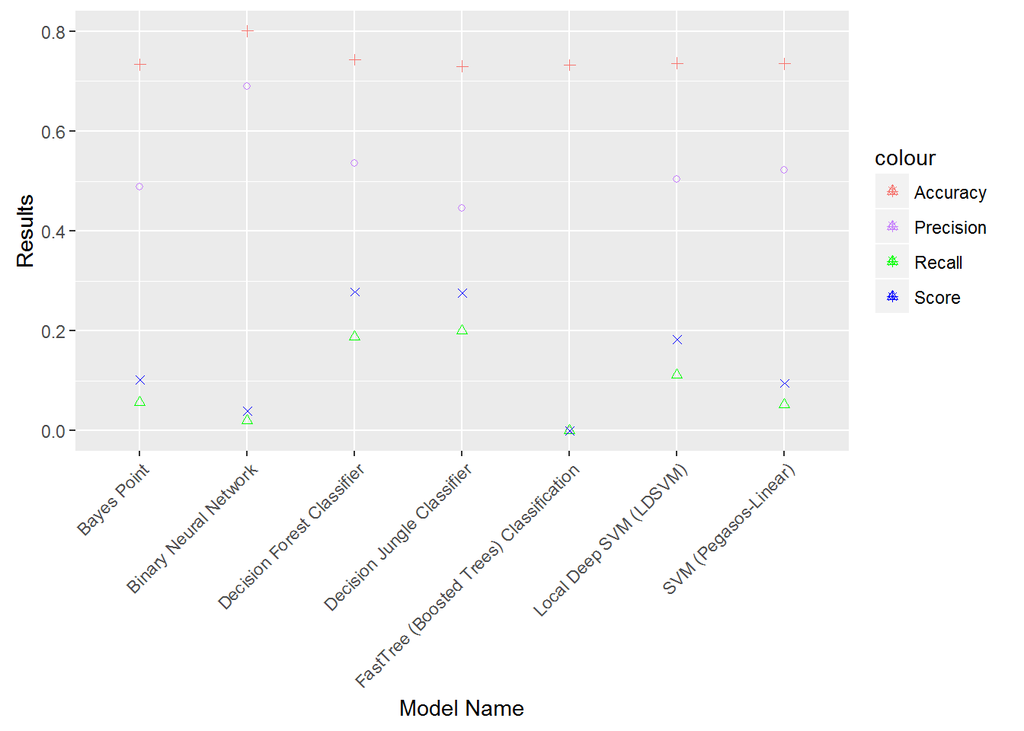

```r
NN_percisions <- c(NN_percisions,summary[2,3]$precision)
DF_precisions <- c(DF_precisions,summary[3,3]$precision)
SVM_precisions <- c(SVM_precisions,summary[7,3]$precision)
NN_acc <- c(NN_acc,summary[2,2]$accuracy)
DF_acc <- c(DF_acc,summary[3,2]$accuracy)
SVM_acc <- c(SVM_acc,summary[7,2]$accuracy)

ggplot(summary, aes(Model)) +
  geom_point(aes(y = precision, colour ='Precision'), size=1.5, group = 1, shape=1) +
  geom_point(aes(y = recall, colour = 'Recall'), size= 1.5, group = 1, shape=2)+
  geom_point(aes(y = accuracy, colour = 'Accuracy'), size= 1.5, group = 1, shape=3)+
  geom_point(aes(y = F.Score, colour = 'Score'), size= 1.5, group = 1, shape=4)+
  xlab("Model Name")+ylab("Results")  +
  scale_colour_manual(values=c("#F57670","#C680FC","GREEN","BLUE"))+
  #scale_shape_discrete(solid=T, legend=F) +
  theme(axis.text.x = element_text(angle = 45, hjust = 1))
```

Note that Neural Networks has the most accuracy. However we need to check the precision to get a better indicator of the classifier we choose.

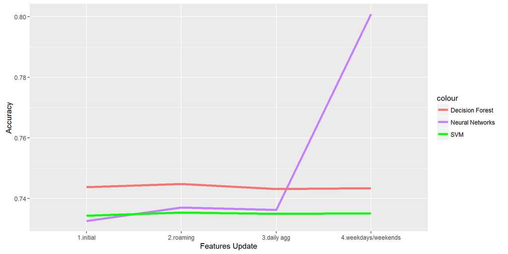

```r
a <- c("1.initial","2.roaming","3.daily agg","4.weekdays/weekends")
df <- data.frame(updates = a, NN = NN_acc, DF =  DF_acc, SVM = SVM_acc)
ggplot(df, aes(updates)) +
  geom_line(aes(y = NN, colour = "Neural Networks"), size=1.5, group = 1) +
  geom_line(aes(y = DF, colour = "Decision Forest"), size=1.5, group = 1) +
  geom_line(aes(y = SVM, colour = "SVM"), size=1.5, group = 1) +
  xlab("Features Update")+ylab("Accuracy")  +
  scale_colour_manual(values=c("#F57670","#C680FC","#00FF00"))
```

We can see that the precision of Neural Networks increases as we add our new features ad addition it achievs the best best precision among the other classifiers.

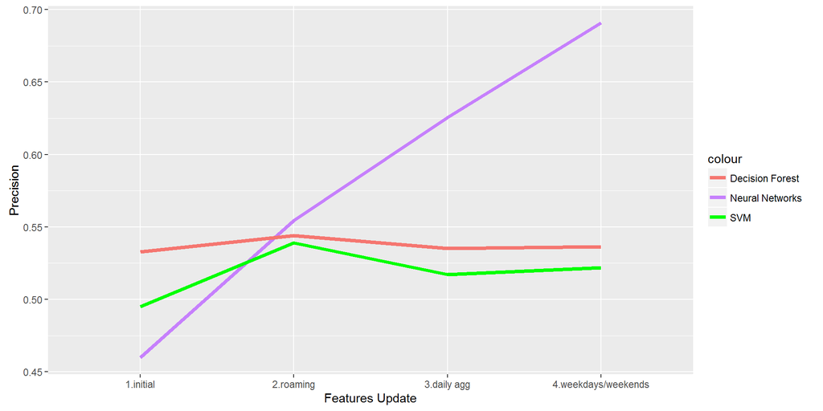

```r
df <- data.frame(updates = a, NN = NN_percisions, DF =  DF_precisions, SVM = SVM_precisions)
ggplot(df, aes(updates)) +
  geom_line(aes(y = NN, colour = "Neural Networks"), size=1.5, group = 1) +
  geom_line(aes(y = DF, colour = "Decision Forest"), size=1.5, group = 1) +
  geom_line(aes(y = SVM, colour = "SVM"), size=1.5, group = 1) +
  xlab("Features Update")+ylab("Precision")  +
  scale_colour_manual(values=c("#F57670","#C680FC","#00FF00"))
```

# Evaluating our model(Mimi)

# Paramters Selection

For Random forest classifiers we set the the number of tree in the range of (64-128) according to this [article](https://www.researchgate.net/publication/230766603_How_Many_Trees_in_a_Random_Forest) which balance between the performance and the time in training.

When using Azure classsifers We used range parameter to calculate the optimal parametrs as we couldn’t invesitage in each classifier internally.